# Lending Club - Macro Effect

*Effect of Macro factors such as Unemployment Rate on Lending Club Loans*

### Summary

Six different regressions are performed to analyze the lending club loans. They are ordered as below

1. California Loans 2012-2015 Issuance
2. All State Loans 2012Q1 - 2013Q3 Issuance (using Unemployment Rate at Issuance)
3. All State Loans 2012Q1 - 2013Q3 Issuance (using Unemployment Rate Monthly)
4. All State Loans 2011 - 2015 Issuance (using Unemployment Rate Monthly)
5. All State Loans 2011 - 2015 Issuance (using Unemployment Rate at Issuance)
6. All State Loans 2011 - 2015 Issuance (using FICO scores + Unemp Issuance + Unemp Monthly)

In all the models above `Interest Rate` at issuance is included in the model

#### Load Libraries

```r
library(data.table)
library(tidyverse)
library(lubridate)
library(survival)
library(survminer)
```

### Analyze Lending Club loans 2012-2015

**(California)**

Sample Data is for loans issues from 2012 through to 2015 onwards in the state of California with a 36 month term. A random sample of 1000 such loans is chosen for the analysis

```r
loan_sample<-read.csv("Sample Loans CA 36 2012_2015.csv", header=T)
head(loan_sample)
```

|  | X | id | loan_amnt | term | int_rate | issue_d | last_pymnt_d | addr_state | MATURITY | VINTAGE | MONTH_BEGIN_PAY_DT | MONTH_END_PAY_DT | MONTH.AGE.BEGIN | MONTH.AGE.END | DEFAULT | DELINQ | FULLPAID | CURRENT | PREPAID | UNEMP.RT_ISS | UNEMP.RT.BEGIN_DT |
| --- | --- | --- | --- | --- | --- | --- | --- | --- | --- | --- | --- | --- | --- | --- | --- | --- | --- | --- | --- | --- | --- |
| 1 | 1 | 469680 | 17600 | 36 months | 8.67 | 2014-11-01 | 2015-10-01 | CA | 2017-11-01 | 2014 | 2014-11-01 | 2014-12-01 | 0 | 1 | 0 | 0 | 1 | 0 | 1 | 7 | 7.0 |
| 2 | 2 | 469680 | 17600 | 36 months | 8.67 | 2014-11-01 | 2015-10-01 | CA | 2017-11-01 | 2014 | 2014-12-01 | 2015-01-01 | 1 | 2 | 0 | 0 | 1 | 0 | 1 | 7 | 6.9 |
| 3 | 3 | 469680 | 17600 | 36 months | 8.67 | 2014-11-01 | 2015-10-01 | CA | 2017-11-01 | 2014 | 2015-01-01 | 2015-02-01 | 2 | 3 | 0 | 0 | 1 | 0 | 1 | 7 | 6.8 |
| 4 | 4 | 469680 | 17600 | 36 months | 8.67 | 2014-11-01 | 2015-10-01 | CA | 2017-11-01 | 2014 | 2015-02-01 | 2015-03-01 | 3 | 4 | 0 | 0 | 1 | 0 | 1 | 7 | 6.6 |
| 5 | 5 | 469680 | 17600 | 36 months | 8.67 | 2014-11-01 | 2015-10-01 | CA | 2017-11-01 | 2014 | 2015-03-01 | 2015-04-01 | 4 | 5 | 0 | 0 | 1 | 0 | 1 | 7 | 6.5 |
| 6 | 6 | 469680 | 17600 | 36 months | 8.67 | 2014-11-01 | 2015-10-01 | CA | 2017-11-01 | 2014 | 2015-04-01 | 2015-05-01 | 5 | 6 | 0 | 0 | 1 | 0 | 1 | 7 | 6.4 |

#### Selecting Data

**(California)**

- Remove records for loan status after Oct 2016 (inclusive) to avoid dealing with Delinquent loans
- Normalize Unemployment Rate at begin date and interest rate columns by subtracting means
- Select the columns which are going to be used in the model only
- Factorize the age of the loan

```r
loan_sample_model<-as.tbl(loan_sample)%>%
    filter(as.Date(MONTH_BEGIN_PAY_DT,origin=Sys.Date()) <
               as.Date("2016-10-01",origin=Sys.Date()))%>%
    select(id,int_rate,MONTH.AGE.BEGIN,DEFAULT,UNEMP.RT.BEGIN_DT)%>%
    mutate(int_rate = int_rate-mean(int_rate))%>%
    mutate(UNEMP.RT.BEGIN_DT = UNEMP.RT.BEGIN_DT-mean(UNEMP.RT.BEGIN_DT))%>%
    mutate(MONTH.AGE.BEGIN = as.factor(MONTH.AGE.BEGIN))
head(loan_sample_model)
```

| id | int_rate | MONTH.AGE.BEGIN | DEFAULT | UNEMP.RT.BEGIN_DT |
| --- | --- | --- | --- | --- |
| 469680 | -3.608345 | 0 | 0 | 0.40374381 |
| 469680 | -3.608345 | 1 | 0 | 0.30374381 |
| 469680 | -3.608345 | 2 | 0 | 0.20374381 |
| 469680 | -3.608345 | 3 | 0 | 0.00374381 |
| 469680 | -3.608345 | 4 | 0 | -0.09625619 |
| 469680 | -3.608345 | 5 | 0 | -0.19625619 |

**(California)**

```r
all_model_stats<-rbind(model_stats,all_model_stats)
```

[output not shown]

#### Baseline Hazard Rate for Loans

**(California)**

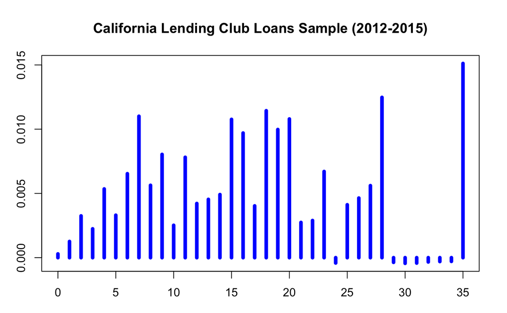

```r
par(mar = c(3,3,4,2))
plot(x = loan_linear_mdl$xlevels$MONTH.AGE.BEGIN,
     y = loan_linear_mdl$coefficients[-(1:2)],
     type = 'h',
     lwd=5,
     col = 'blue',
     xlab = "Age of Loan (months)",
     ylab = "Default Rate",
     main = "California Lending Club Loans Sample (2012-2015)")
```

### Analyzing All States Sample for loans

**(2012-2013Q3 Unemployment Issuance)**

Sample Data is for loans issues from 1-Jan-2012 through to 30-Sep-2013, in all the states in the US with a 36 month term. A random sample of 10,000 such loans is chosen for the analysis

```r
loan_sample_all_2012_2013<-fread("Sample Loans 36 2012_2013.csv", header=T)
head(loan_sample_all_2012_2013)
```

| V1 | id | loan_amnt | term | int_rate | issue_d | last_pymnt_d | addr_state | fico_range_low | MATURITY | VINTAGE | MONTH_BEGIN_PAY_DT | MONTH_END_PAY_DT | MONTH.AGE.BEGIN | MONTH.AGE.END | DEFAULT | DELINQ | FULLPAID | CURRENT | PREPAID | UNEMP.RT_ISS | UNEMP.RT.BEGIN_DT |
| --- | --- | --- | --- | --- | --- | --- | --- | --- | --- | --- | --- | --- | --- | --- | --- | --- | --- | --- | --- | --- | --- |
| 1 | 546966 | 7700 | 36 months | 10.16 | 2013-06-01 | 2014-04-01 | PA | 705 | 2016-06-01 | 2013 | 2013-06-01 | 2013-07-01 | 0 | 1 | 0 | 0 | 1 | 0 | 1 | 7.1 | 7.1 |
| 2 | 546966 | 7700 | 36 months | 10.16 | 2013-06-01 | 2014-04-01 | PA | 705 | 2016-06-01 | 2013 | 2013-07-01 | 2013-08-01 | 1 | 2 | 0 | 0 | 1 | 0 | 1 | 7.1 | 7.1 |
| 3 | 546966 | 7700 | 36 months | 10.16 | 2013-06-01 | 2014-04-01 | PA | 705 | 2016-06-01 | 2013 | 2013-08-01 | 2013-09-01 | 2 | 3 | 0 | 0 | 1 | 0 | 1 | 7.1 | 7.0 |
| 4 | 546966 | 7700 | 36 months | 10.16 | 2013-06-01 | 2014-04-01 | PA | 705 | 2016-06-01 | 2013 | 2013-09-01 | 2013-10-01 | 3 | 4 | 0 | 0 | 1 | 0 | 1 | 7.1 | 6.9 |
| 5 | 546966 | 7700 | 36 months | 10.16 | 2013-06-01 | 2014-04-01 | PA | 705 | 2016-06-01 | 2013 | 2013-10-01 | 2013-11-01 | 4 | 5 | 0 | 0 | 1 | 0 | 1 | 7.1 | 6.8 |
| 6 | 546966 | 7700 | 36 months | 10.16 | 2013-06-01 | 2014-04-01 | PA | 705 | 2016-06-01 | 2013 | 2013-11-01 | 2013-12-01 | 5 | 6 | 0 | 0 | 1 | 0 | 1 | 7.1 | 6.7 |

#### Selecting Data

**(2012-2013Q3 Unemployment Issuance)**

- Remove records for loan status after Oct 2016 (inclusive) to avoid dealing with Delinquent loans
- Normalize Unemployment Rate at begin date and interest rate columns by subtracting means
- Select the columns which are going to be used in the model only
- Factorize the age of the loan

```r
loan_sample_all_model_2012_2013<-as.tbl(loan_sample_all_2012_2013)%>%
    filter(as.Date(MONTH_BEGIN_PAY_DT,origin=Sys.Date()) <
               as.Date("2016-10-01",origin=Sys.Date()))%>%
    select(id,int_rate,MONTH.AGE.BEGIN,DEFAULT,UNEMP.RT_ISS)%>%
    mutate(int_rate = int_rate-mean(int_rate))%>%
    mutate(UNEMP.RT_ISS = UNEMP.RT_ISS-mean(UNEMP.RT_ISS))%>%
    mutate(MONTH.AGE.BEGIN = as.factor(MONTH.AGE.BEGIN))
```

#### Fit a Linear Model

**(2012-2013Q3 Unemployment Issuance)**

```r
loan_linear_mdl_all_2012_2013<-lm(DEFAULT ~ int_rate + UNEMP.RT_ISS+MONTH.AGE.BEGIN - 1,
                     data = loan_sample_all_model_2012_2013)
model_stats<-model_summary(experiment = 2,
                           model = loan_linear_mdl_all_2012_2013,
                           geography = "ALL",
                           period = "2012Q1-2013Q3")
all_model_stats<-rbind(model_stats,all_model_stats)
```

#### Baseline Hazard Rate for ALL States Loans

**(2012-2013Q3 Unemployment Issuance)**

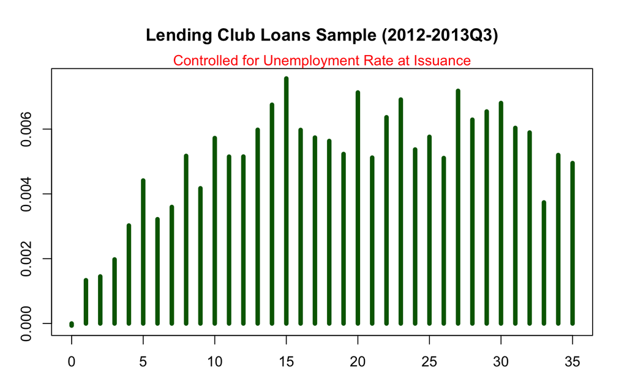

```r
par(mar = c(3,3,4,2))
plot(x = loan_linear_mdl_all_2012_2013$xlevels$MONTH.AGE.BEGIN,
     y = loan_linear_mdl_all_2012_2013$coefficients[-(1:2)],
     type = 'h',
     col = 'darkgreen',
     lwd =5,
     xlab = "Age of Loan (months)",
     ylab = "Default Rate",
     main = "Lending Club Loans Sample (2012-2013Q3)")
mtext("Controlled for Unemployment Rate at Issuance",col="red",side=3)
```

### Analyzing All States Sample for loans

**(2012-2013Q3 Unemployment Monthly)**

Sample Data is for loans issues from 1-Jan-2012 through to 30-Sep-2013, in all the states in the US with a 36 month term. A random sample of 10,000 such loans is chosen for the analysis

```r
loan_sample_all_2012_2013<-fread("Sample Loans 36 2012_2013.csv", header=T)
head(loan_sample_all_2012_2013)
```

| V1 | id | loan_amnt | term | int_rate | issue_d | last_pymnt_d | addr_state | fico_range_low | MATURITY | VINTAGE | MONTH_BEGIN_PAY_DT | MONTH_END_PAY_DT | MONTH.AGE.BEGIN | MONTH.AGE.END | DEFAULT | DELINQ | FULLPAID | CURRENT | PREPAID | UNEMP.RT_ISS | UNEMP.RT.BEGIN_DT |
| --- | --- | --- | --- | --- | --- | --- | --- | --- | --- | --- | --- | --- | --- | --- | --- | --- | --- | --- | --- | --- | --- |
| 1 | 546966 | 7700 | 36 months | 10.16 | 2013-06-01 | 2014-04-01 | PA | 705 | 2016-06-01 | 2013 | 2013-06-01 | 2013-07-01 | 0 | 1 | 0 | 0 | 1 | 0 | 1 | 7.1 | 7.1 |
| 2 | 546966 | 7700 | 36 months | 10.16 | 2013-06-01 | 2014-04-01 | PA | 705 | 2016-06-01 | 2013 | 2013-07-01 | 2013-08-01 | 1 | 2 | 0 | 0 | 1 | 0 | 1 | 7.1 | 7.1 |
| 3 | 546966 | 7700 | 36 months | 10.16 | 2013-06-01 | 2014-04-01 | PA | 705 | 2016-06-01 | 2013 | 2013-08-01 | 2013-09-01 | 2 | 3 | 0 | 0 | 1 | 0 | 1 | 7.1 | 7.0 |
| 4 | 546966 | 7700 | 36 months | 10.16 | 2013-06-01 | 2014-04-01 | PA | 705 | 2016-06-01 | 2013 | 2013-09-01 | 2013-10-01 | 3 | 4 | 0 | 0 | 1 | 0 | 1 | 7.1 | 6.9 |
| 5 | 546966 | 7700 | 36 months | 10.16 | 2013-06-01 | 2014-04-01 | PA | 705 | 2016-06-01 | 2013 | 2013-10-01 | 2013-11-01 | 4 | 5 | 0 | 0 | 1 | 0 | 1 | 7.1 | 6.8 |
| 6 | 546966 | 7700 | 36 months | 10.16 | 2013-06-01 | 2014-04-01 | PA | 705 | 2016-06-01 | 2013 | 2013-11-01 | 2013-12-01 | 5 | 6 | 0 | 0 | 1 | 0 | 1 | 7.1 | 6.7 |

#### Selecting Data

**(2012-2013Q3 Unemployment Monthly)**

- Remove records for loan status after Oct 2016 (inclusive) to avoid dealing with Delinquent loans
- Normalize Unemployment Rate at begin date and interest rate columns by subtracting means
- Select the columns which are going to be used in the model only
- Factorize the age of the loan

```r
loan_sample_all_model_2012_2013<-as.tbl(loan_sample_all_2012_2013)%>%
    filter(as.Date(MONTH_BEGIN_PAY_DT,origin=Sys.Date()) <
               as.Date("2016-10-01",origin=Sys.Date()))%>%
    select(id,int_rate,MONTH.AGE.BEGIN,DEFAULT,UNEMP.RT.BEGIN_DT)%>%
    mutate(int_rate = int_rate-mean(int_rate))%>%
    mutate(UNEMP.RT.BEGIN_DT = UNEMP.RT.BEGIN_DT-mean(UNEMP.RT.BEGIN_DT))%>%
    mutate(MONTH.AGE.BEGIN = as.factor(MONTH.AGE.BEGIN))
```

#### Fit a Linear Model

**(2012-2013Q3 Unemployment Monthly)**

```r
loan_linear_mdl_all_2012_2013_monthly<-lm(DEFAULT ~ int_rate + UNEMP.RT.BEGIN_DT + MONTH.AGE.BEGIN - 1,
                     data = loan_sample_all_model_2012_2013)
model_stats<-model_summary(experiment = 3,
                           model = loan_linear_mdl_all_2012_2013_monthly,
                           geography = "ALL",
                           period = "2012Q1-2013Q3")
all_model_stats<-rbind(model_stats,all_model_stats)
```

#### Baseline Hazard Rate for ALL States Loans

**(2012-2013Q3 Unemployment Monthly)**

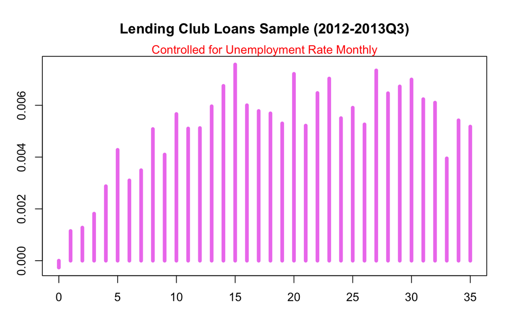

```r
par(mar = c(3,3,4,2))
plot(x = loan_linear_mdl_all_2012_2013_monthly$xlevels$MONTH.AGE.BEGIN,
     y = loan_linear_mdl_all_2012_2013_monthly$coefficients[-(1:2)],
     type = 'h',
     col = 'violet',
     lwd =5,
     xlab = "Age of Loan (months)",
     ylab = "Default Rate",
     main = "Lending Club Loans Sample (2012-2013Q3)")
mtext("Controlled for Unemployment Rate Monthly",col="red",side=3)
```

### Analyzing All States Sample

**(2011-2015 Unemployment Monthly)**

Sample Data is for loans issues from 2011 through to 2015 onwards in all the states in the US with a 36 month term. A random sample of 100,000 such loans is chosen for the analysis

```r
loan_sample_all<-fread("Sample Loans 36 2011_2015.csv", header=T)
```

```
Read 44.0% of 2159792 rows
Read 81.0% of 2159792 rows
Read 2159792 rows and 22 (of 22) columns from 0.276 GB file in 00:00:04
```

```r
head(loan_sample_all)
```

| V1 | id | loan_amnt | term | int_rate | issue_d | last_pymnt_d | addr_state | fico_range_low | MATURITY | VINTAGE | MONTH_BEGIN_PAY_DT | MONTH_END_PAY_DT | MONTH.AGE.BEGIN | MONTH.AGE.END | DEFAULT | DELINQ | FULLPAID | CURRENT | PREPAID | UNEMP.RT_ISS | UNEMP.RT.BEGIN_DT |
| --- | --- | --- | --- | --- | --- | --- | --- | --- | --- | --- | --- | --- | --- | --- | --- | --- | --- | --- | --- | --- | --- |
| 1 | 300390 | 12000 | 36 months | 6.49 | 2014-12-01 | 2017-03-01 | NJ | 715 | 2017-12-01 | 2014 | 2014-12-01 | 2015-01-01 | 0 | 1 | 0 | 0 | 0 | 1 | 0 | 6.6 | 6.6 |
| 2 | 300390 | 12000 | 36 months | 6.49 | 2014-12-01 | 2017-03-01 | NJ | 715 | 2017-12-01 | 2014 | 2015-01-01 | 2015-02-01 | 1 | 2 | 0 | 0 | 0 | 1 | 0 | 6.6 | 6.5 |
| 3 | 300390 | 12000 | 36 months | 6.49 | 2014-12-01 | 2017-03-01 | NJ | 715 | 2017-12-01 | 2014 | 2015-02-01 | 2015-03-01 | 2 | 3 | 0 | 0 | 0 | 1 | 0 | 6.6 | 6.4 |
| 4 | 300390 | 12000 | 36 months | 6.49 | 2014-12-01 | 2017-03-01 | NJ | 715 | 2017-12-01 | 2014 | 2015-03-01 | 2015-04-01 | 3 | 4 | 0 | 0 | 0 | 1 | 0 | 6.6 | 6.3 |
| 5 | 300390 | 12000 | 36 months | 6.49 | 2014-12-01 | 2017-03-01 | NJ | 715 | 2017-12-01 | 2014 | 2015-04-01 | 2015-05-01 | 4 | 5 | 0 | 0 | 0 | 1 | 0 | 6.6 | 6.2 |
| 6 | 300390 | 12000 | 36 months | 6.49 | 2014-12-01 | 2017-03-01 | NJ | 715 | 2017-12-01 | 2014 | 2015-05-01 | 2015-06-01 | 5 | 6 | 0 | 0 | 0 | 1 | 0 | 6.6 | 6.0 |

#### Selecting Data

**(2011-2015 Unemployment Monthly)**

- Remove records for loan status after Oct 2016 (inclusive) to avoid dealing with Delinquent loans
- Normalize Unemployment Rate at begin date and interest rate columns by subtracting means
- Select the columns which are going to be used in the model only
- Factorize the age of the loan

```r
loan_sample_all_model<-as.tbl(loan_sample_all)%>%
    filter(as.Date(MONTH_BEGIN_PAY_DT,origin=Sys.Date()) <
               as.Date("2016-10-01",origin=Sys.Date()))%>%
    select(id,int_rate,MONTH.AGE.BEGIN,DEFAULT,UNEMP.RT.BEGIN_DT)%>%
    mutate(int_rate = int_rate-mean(int_rate))%>%
    mutate(UNEMP.RT.BEGIN_DT = UNEMP.RT.BEGIN_DT-mean(UNEMP.RT.BEGIN_DT))%>%
    mutate(MONTH.AGE.BEGIN = as.factor(MONTH.AGE.BEGIN))
head(loan_sample_all_model)
```

| id | int_rate | MONTH.AGE.BEGIN | DEFAULT | UNEMP.RT.BEGIN_DT |
| --- | --- | --- | --- | --- |
| 300390 | -5.642813 | 0 | 0 | 0.8707959 |
| 300390 | -5.642813 | 1 | 0 | 0.7707959 |
| 300390 | -5.642813 | 2 | 0 | 0.6707959 |
| 300390 | -5.642813 | 3 | 0 | 0.5707959 |
| 300390 | -5.642813 | 4 | 0 | 0.4707959 |
| 300390 | -5.642813 | 5 | 0 | 0.2707959 |

#### Fit a Linear Model

**(2011-2015 Unemployment Monthly)**

```r
loan_linear_mdl_all_monthly<-lm(DEFAULT ~ int_rate + UNEMP.RT.BEGIN_DT+MONTH.AGE.BEGIN - 1,
                     data = loan_sample_all_model)
model_stats<-model_summary(experiment = 2,
                           model = loan_linear_mdl_all_monthly,
                           geography = "ALL",
                           period = "2011-2015")
all_model_stats<-rbind(model_stats,all_model_stats)
```

#### Baseline Hazard Rate for ALL States Loans

**(2011-2015 Unemployment Monthly)**

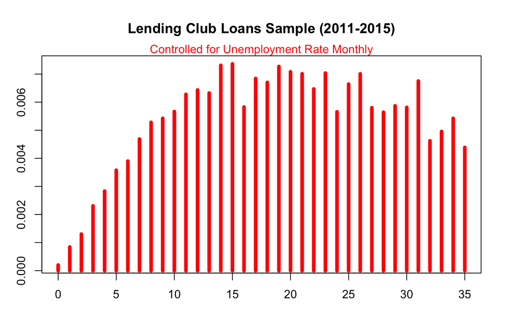

```r
par(mar=c(3,3,4,2))
plot(x = loan_linear_mdl_all_monthly$xlevels$MONTH.AGE.BEGIN,
     y = loan_linear_mdl_all_monthly$coefficients[-(1:2)],
     type = 'h',
     col = 'red',
     lwd=5,
     xlab = "Age of Loan (months)",
     ylab = "Default Rate",
     main = "Lending Club Loans Sample (2011-2015)")
mtext("Controlled for Unemployment Rate Monthly",col="red",side=3)
```

### Analyzing and Selecting Data ALL states Loans

**(2011-2015 Unemployment Issue Date)**

```r
loan_sample_all_model_uis<-as.tbl(loan_sample_all)%>%
    filter(as.Date(MONTH_BEGIN_PAY_DT,origin=Sys.Date()) <
               as.Date("2016-10-01",origin=Sys.Date()))%>%
    select(id,int_rate,MONTH.AGE.BEGIN,DEFAULT,UNEMP.RT_ISS,UNEMP.RT.BEGIN_DT)%>%
    mutate(int_rate = int_rate-mean(int_rate))%>%
    mutate(UNEMP.RT.BEGIN_DT = UNEMP.RT.BEGIN_DT-mean(UNEMP.RT.BEGIN_DT))%>%
    mutate(UNEMP.RT_ISS = UNEMP.RT_ISS-mean(UNEMP.RT_ISS))%>%
    mutate(MONTH.AGE.BEGIN = as.factor(MONTH.AGE.BEGIN))
head(loan_sample_all_model_uis)
```

[output not shown]

**(2011-2015 Unemployment Issue Date)**

#### Baseline Hazard Rate for ALL States Loans

**(2011-2015 Unemployment Issue Date)**

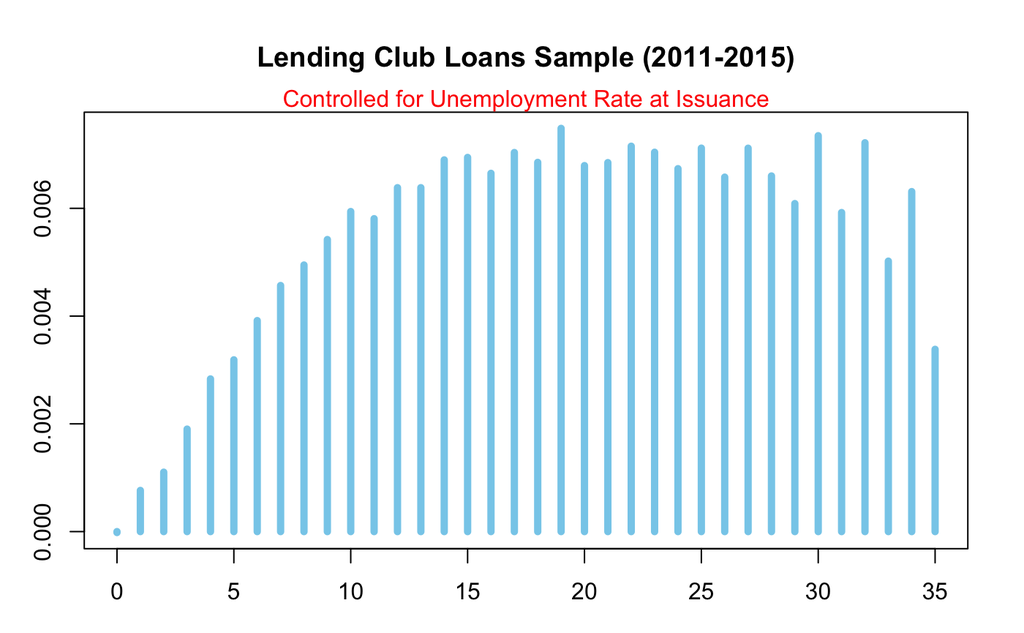

```r
par(mar = c(3,3,4,2))
plot(x = loan_linear_mdl_all_uis$xlevels$MONTH.AGE.BEGIN,
     y = loan_linear_mdl_all_uis$coefficients[-(1:2)],
     type = 'h',
     col = 'skyblue',
     lwd =5,
     xlab = "Age of Loan (months)",
     ylab = "Default Rate",
     main = "Lending Club Loans Sample (2011-2015)" )
mtext("Controlled for Unemployment Rate at Issuance",col="red",side=3)
```

### Analyzing loans (2011-2015)

**With FICO Scores**

Sample Data is for loans issues from 2011 through to 2015, in all the states in the US with a 36 month term. A random sample of 100,000 such loans is chosen for the analysis

```r
loan_sample_all<-fread("Sample Loans 36 2011_2015.csv", header=T)
```

```
Read 49.1% of 2159792 rows
Read 85.7% of 2159792 rows
Read 2159792 rows and 22 (of 22) columns from 0.276 GB file in 00:00:04
```

```r
head(loan_sample_all)
```

| V1 | id | loan_amnt | term | int_rate | issue_d | last_pymnt_d | addr_state | fico_range_low | MATURITY | VINTAGE | MONTH_BEGIN_PAY_DT | MONTH_END_PAY_DT | MONTH.AGE.BEGIN | MONTH.AGE.END | DEFAULT | DELINQ | FULLPAID | CURRENT | PREPAID | UNEMP.RT_ISS | UNEMP.RT.BEGIN_DT |
| --- | --- | --- | --- | --- | --- | --- | --- | --- | --- | --- | --- | --- | --- | --- | --- | --- | --- | --- | --- | --- | --- |
| 1 | 300390 | 12000 | 36 months | 6.49 | 2014-12-01 | 2017-03-01 | NJ | 715 | 2017-12-01 | 2014 | 2014-12-01 | 2015-01-01 | 0 | 1 | 0 | 0 | 0 | 1 | 0 | 6.6 | 6.6 |
| 2 | 300390 | 12000 | 36 months | 6.49 | 2014-12-01 | 2017-03-01 | NJ | 715 | 2017-12-01 | 2014 | 2015-01-01 | 2015-02-01 | 1 | 2 | 0 | 0 | 0 | 1 | 0 | 6.6 | 6.5 |
| 3 | 300390 | 12000 | 36 months | 6.49 | 2014-12-01 | 2017-03-01 | NJ | 715 | 2017-12-01 | 2014 | 2015-02-01 | 2015-03-01 | 2 | 3 | 0 | 0 | 0 | 1 | 0 | 6.6 | 6.4 |
| 4 | 300390 | 12000 | 36 months | 6.49 | 2014-12-01 | 2017-03-01 | NJ | 715 | 2017-12-01 | 2014 | 2015-03-01 | 2015-04-01 | 3 | 4 | 0 | 0 | 0 | 1 | 0 | 6.6 | 6.3 |
| 5 | 300390 | 12000 | 36 months | 6.49 | 2014-12-01 | 2017-03-01 | NJ | 715 | 2017-12-01 | 2014 | 2015-04-01 | 2015-05-01 | 4 | 5 | 0 | 0 | 0 | 1 | 0 | 6.6 | 6.2 |
| 6 | 300390 | 12000 | 36 months | 6.49 | 2014-12-01 | 2017-03-01 | NJ | 715 | 2017-12-01 | 2014 | 2015-05-01 | 2015-06-01 | 5 | 6 | 0 | 0 | 0 | 1 | 0 | 6.6 | 6.0 |

#### Selecting Data

**With FICO Scores**

- Remove records for loan status after Oct 2016 (inclusive) to avoid dealing with Delinquent loans
- Normalize Unemployment Rate at begin date and interest rate columns by subtracting means
- Select the columns which are going to be used in the model only
- Factorize the age of the loan

```r
loan_sample_all_model_fico<-as.tbl(loan_sample_all)%>%
    filter(as.Date(MONTH_BEGIN_PAY_DT,origin=Sys.Date()) <
               as.Date("2016-10-01",origin=Sys.Date()))%>%
    select(id,int_rate,fico_range_low,MONTH.AGE.BEGIN,DEFAULT,UNEMP.RT_ISS,UNEMP.RT.BEGIN_DT)%>%
    mutate(int_rate = int_rate-mean(int_rate))%>%
    mutate(UNEMP.RT.BEGIN_DT = UNEMP.RT.BEGIN_DT-mean(UNEMP.RT.BEGIN_DT))%>%
    mutate(UNEMP.RT_ISS = UNEMP.RT_ISS-mean(UNEMP.RT_ISS))%>%
    mutate(fico_range_low = fico_range_low-mean(fico_range_low))%>%
    mutate(MONTH.AGE.BEGIN = as.factor(MONTH.AGE.BEGIN))
head(loan_sample_all_model_fico)
```

| id | int_rate | fico_range_low | MONTH.AGE.BEGIN | DEFAULT | UNEMP.RT_ISS | UNEMP.RT.BEGIN_DT |
| --- | --- | --- | --- | --- | --- | --- |
| 300390 | -5.642813 | 19.96903 | 0 | 0 | 0.1083477 | 0.8707959 |
| 300390 | -5.642813 | 19.96903 | 1 | 0 | 0.1083477 | 0.7707959 |
| 300390 | -5.642813 | 19.96903 | 2 | 0 | 0.1083477 | 0.6707959 |
| 300390 | -5.642813 | 19.96903 | 3 | 0 | 0.1083477 | 0.5707959 |
| 300390 | -5.642813 | 19.96903 | 4 | 0 | 0.1083477 | 0.4707959 |
| 300390 | -5.642813 | 19.96903 | 5 | 0 | 0.1083477 | 0.2707959 |

**With FICO Scores**

#### Baseline Hazard Rate for ALL States Loans

**With FICO Scores**

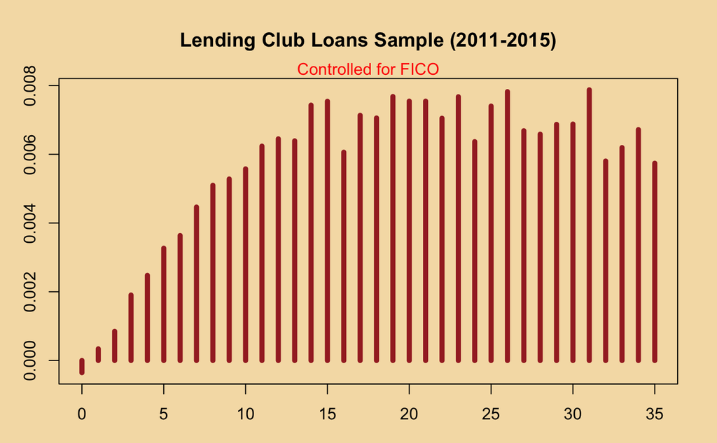

```r
par(mar = c(3,3,4,2),bg="wheat" )
plot(x = loan_linear_mdl_all_fico$xlevels$MONTH.AGE.BEGIN,
     y = loan_linear_mdl_all_fico$coefficients[-(1:4)],
     type = 'h',
     col = "brown",
     lwd =5,
     xlab = "Age of Loan (months)",
     ylab = "Default Rate",
     main = "Lending Club Loans Sample (2011-2015)" )
mtext("Controlled for FICO",col="red",side=3)
```